# BM432 Data Visualisation Workshop

## Critique 2.1

**Issue**

UMAP plots (B, E) are highly manipulable and clustering/placement does not necessarily reflect objective measures.

**Solution**

Be cautious of over-interpretation of UMAP and other nonlinear dimensionality reduction plots.

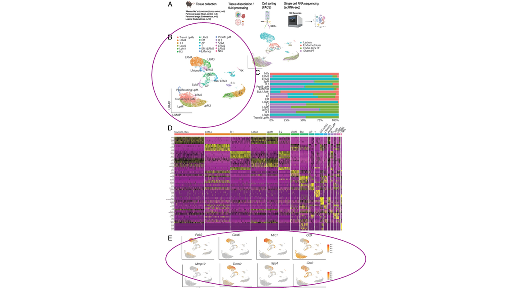

## Critique 2.2

**Issue**

Unpleasant clashing (`R` default) colour choices in (C).

**Solution**

Use an appropriate colour palette.

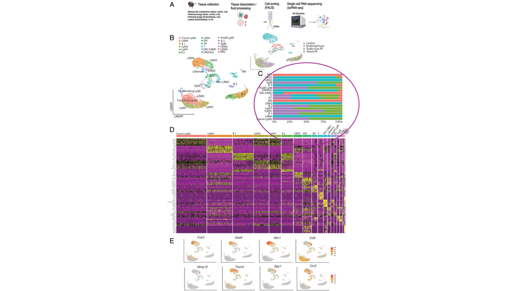

## Critique 2.3

**Issue**

The proportion plot in (C) does not give information on absolute number, only proportion/composition.

**Solution**

A proportional areas plot spanning all clusters would represent both absolute count per group and compositional information.

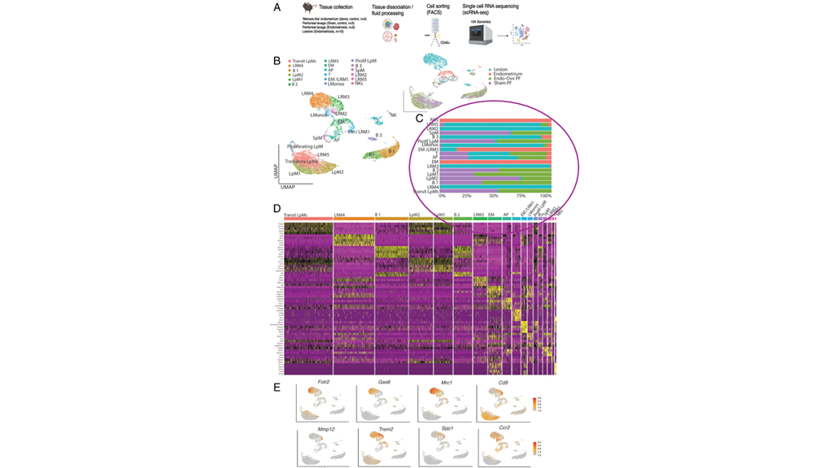

## Critique 2.4

**Issue**

Heatmap text is too small to read comfortably.

**Solution**

Present heatmap as a separate figure, or reduce the amount of information in the image.

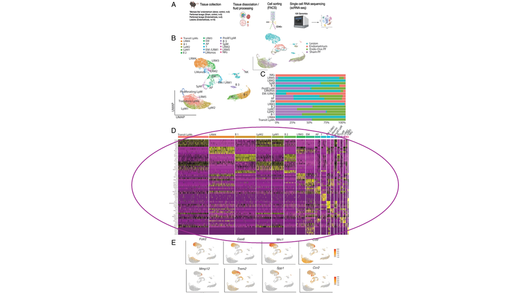

## Critique 2.5

**Issue**

Heatmap is missing a scale (is purple high and yellow low, or vice versa?)

**Solution**

Add a scale bar.

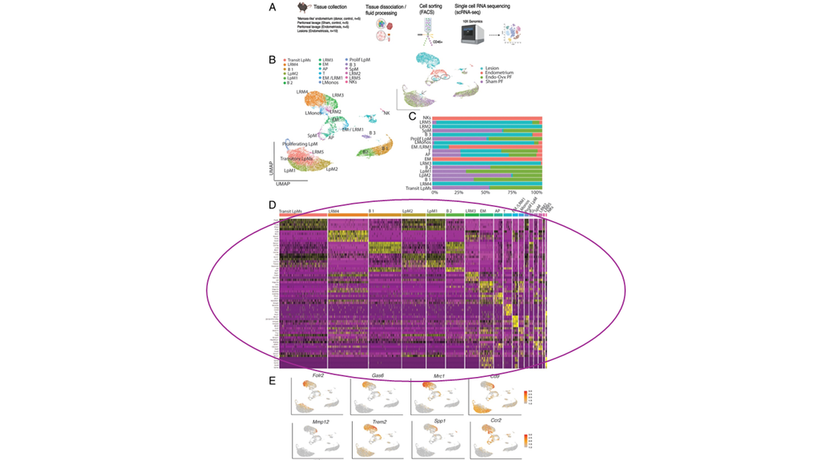

## Critique 2.6

**Issue**

The experimental summary in (A) does not indicate order of operations.

**Solution**

Use arrows to indicate order of steps and/or dataflow.

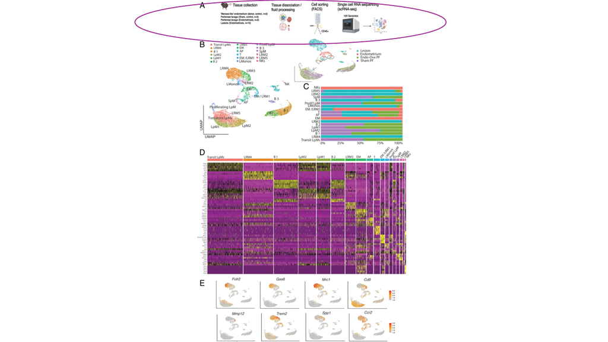

## Critique 2.7

**Issue**

Text is too small in general to read comfortably.

**Solution**

Increase font size and/or break up the panels into individual figures.

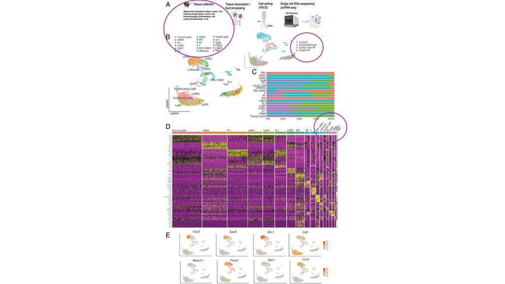

## Critique 2.8

**Issue**

The figure is crowded and the separation of panels is unclear.

**Solution**

Use whitespace to guide reader “flow” through the figure and reduce crowding -in particular, cramming (C) under the inset from (B) makes the figure feel very crowded. Alternatively break the panels into multiple figures.

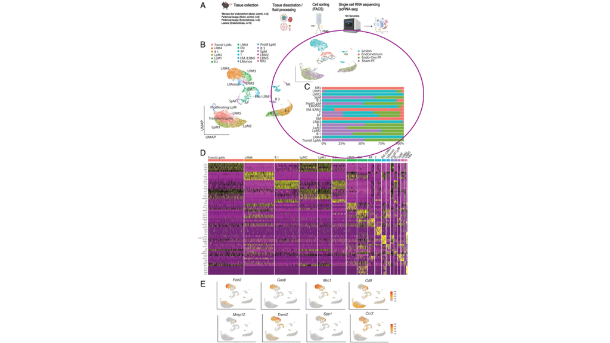

## Critique 2.9

**Issue**

The overall message of the figure is unclear.

**Solution**

If the intent is just that the macrophages exhibit transcriptional heterogeneity, then (D) is probably sufficient. If other messages are intended, then revise for clarity.

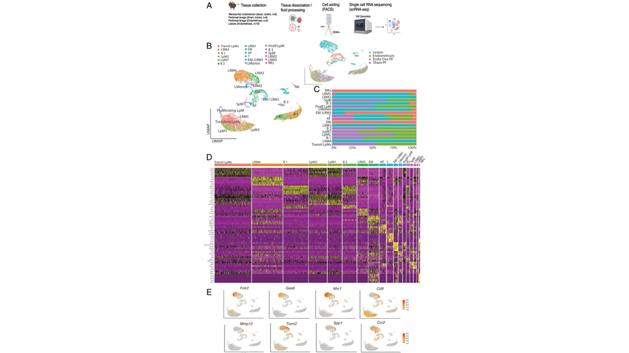

## Our Critical Analysis

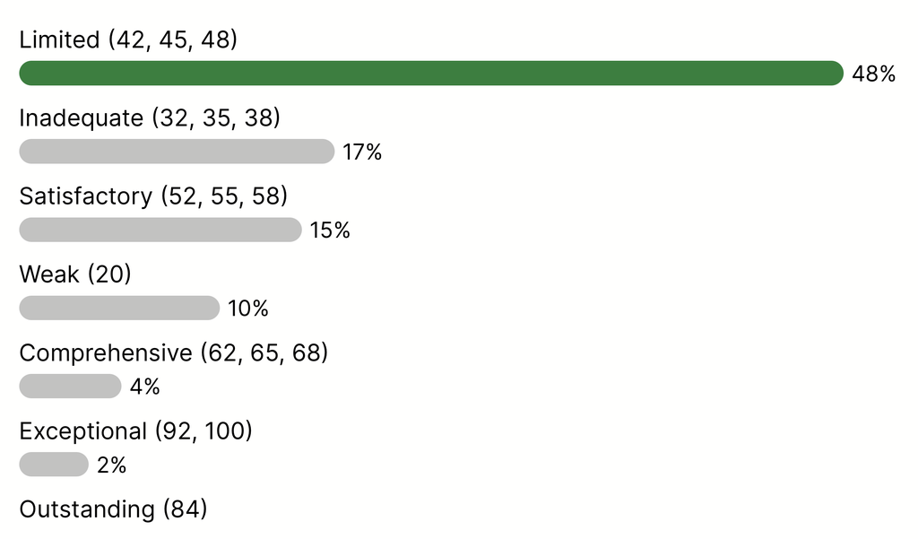

Post-survey results

## Example 3

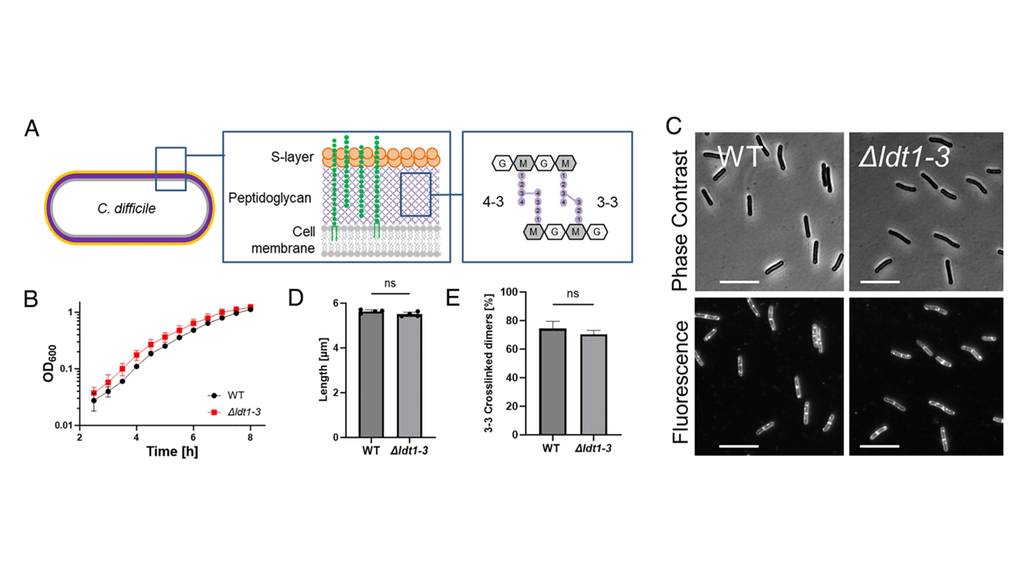

Figure 3: A *C. difficile* mutant lacking all three YkuD-type Ldts ($\Delta$*ldt1-3*) exhibits wild-type growth, morphology, and 3-3 cross-linking.

## Your Critical Analysis of Example 3

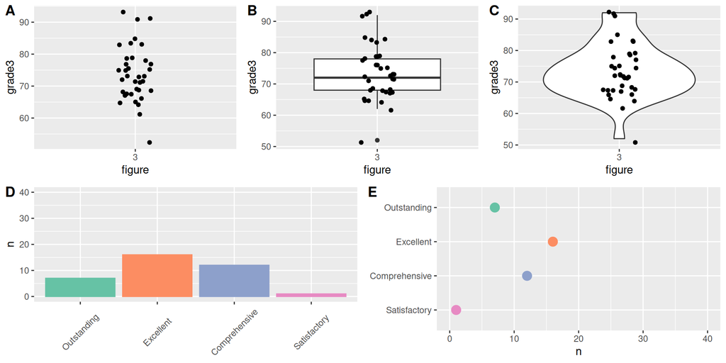